# Team.Rmd

Jacob Shoemaker; jshoemaker2249, Qinwen Yang; AngelQinwen

2/27/2019

1. Data Cleaning

```r
HAPPY <- readRDS("HAPPY.rds")
```

```r
HAPPY[HAPPY == "IAP" | HAPPY == "DK"| HAPPY == "NA"] <- NA
```

```r
HAPPY$HAPPY <- as.factor(HAPPY$HAPPY)
HAPPY$SEX <- as.factor(HAPPY$SEX)
HAPPY$MARITAL <- as.factor(HAPPY$MARITAL)
HAPPY$DEGREE <- as.factor(HAPPY$DEGREE)
HAPPY$FINRELA <- as.factor(HAPPY$FINRELA)
HAPPY$HEALTH <- as.factor(HAPPY$HEALTH)
HAPPY$PARTYID <- as.factor(HAPPY$PARTYID)
HAPPY$POLVIEWS <- as.factor(HAPPY$POLVIEWS)
HAPPY$AGE <- as.numeric(HAPPY$AGE)
HAPPY$AGE <- ifelse(HAPPY$AGE == "89 OR OLDER", 89, HAPPY$AGE)
```

```r
#Order Degree
HAPPY$DEGREE <- factor(HAPPY$DEGREE, levels = c("LT HIGH SCHOOL", "HIGH SCHOOL", "JUNIOR COLLEGE", "BACHELOR", "GRADUATE"))

#Order Opinion of Financial Standing
HAPPY$FINRELA <- factor(HAPPY$FINRELA, levels = c("FAR BELOW AVERAGE", "BELOW AVERAGE", "AVERAGE", "ABOVE AVERAGE", "FAR ABOVE AVERAGE"))

#Order Health
HAPPY$HEALTH <- factor(HAPPY$HEALTH, levels = c("POOR", "FAIR", "GOOD", "EXCELLENT"))

#Order Political Party
HAPPY$PARTYID <- factor(HAPPY$PARTYID, levels= unique(c("STRONG DEMOCRAT", "NOT STR DEMOCRAT", "IND,NEAR DEM","INDEPENDENT", "IND,NEAR REP", "NOT STR REPUBLICAN", "STRONG REPUBLICAN", "INDEPENDENT")))

#Order Political Views
HAPPY$POLVIEWS <- factor(HAPPY$POLVIEWS, levels = c("EXTREMELY LIBERAL", "LIBERAL", "SLIGHTLY LIBERAL", "MODERATE", "SLIGHTLY CONSERVATIVE", "CONSERVATIVE", "EXTRMLY CONSERVATIVE"))

#Order Happiness Level
HAPPY$HAPPY <- factor(HAPPY$HAPPY, levels = c("NOT TOO HAPPY", "PRETTY HAPPY", "VERY HAPPY"))


#Find average age of each marital status
mean(HAPPY$AGE[HAPPY$MARITAL == "NEVER MARRIED"], na.rm = TRUE)
```

```
## [1] 32.48837
```

```r
mean(HAPPY$AGE[HAPPY$MARITAL == "MARRIED"], na.rm = TRUE)
```

```
## [1] 46.51856
```

```r
mean(HAPPY$AGE[HAPPY$MARITAL == "SEPARATED"], na.rm = TRUE)
```

```
## [1] 43.39359
```

```r
mean(HAPPY$AGE[HAPPY$MARITAL == "DIVORCED"], na.rm = TRUE)
```

```
## [1] 48.25022
```

```r
mean(HAPPY$AGE[HAPPY$MARITAL == "WIDOWED"], na.rm = TRUE)
```

```
## [1] 69.28126
```

```r
#Order Marital Status in ascending order of these averages
HAPPY$MARITAL <- factor(HAPPY$MARITAL, levels = c("NEVER MARRIED", "SEPARATED", "MARRIED", "DIVORCED", "WIDOWED"))
```

2. Data Exploring

# Investigate the distributions of 2 different variables

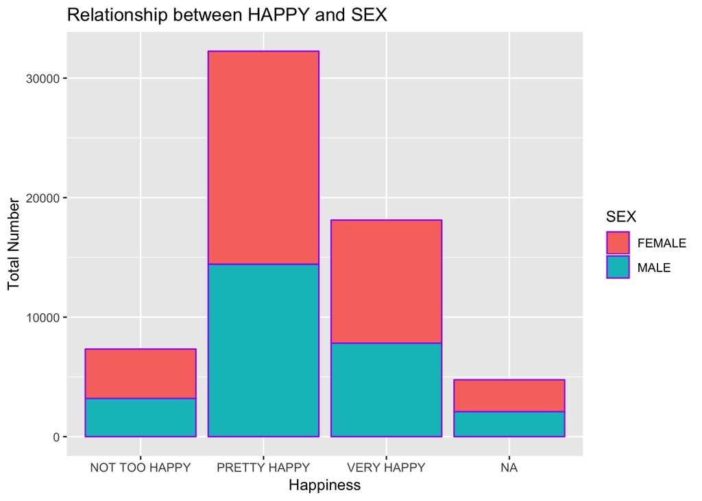

```r
library(ggplot2)

ggplot(HAPPY, aes(x=HAPPY, fill = SEX))+geom_bar(na.rm=TRUE, color="purple",size=0.5)+ylab('Total Number')+xlab('Happiness')+ggtitle("Relationship between HAPPY and SEX")
```

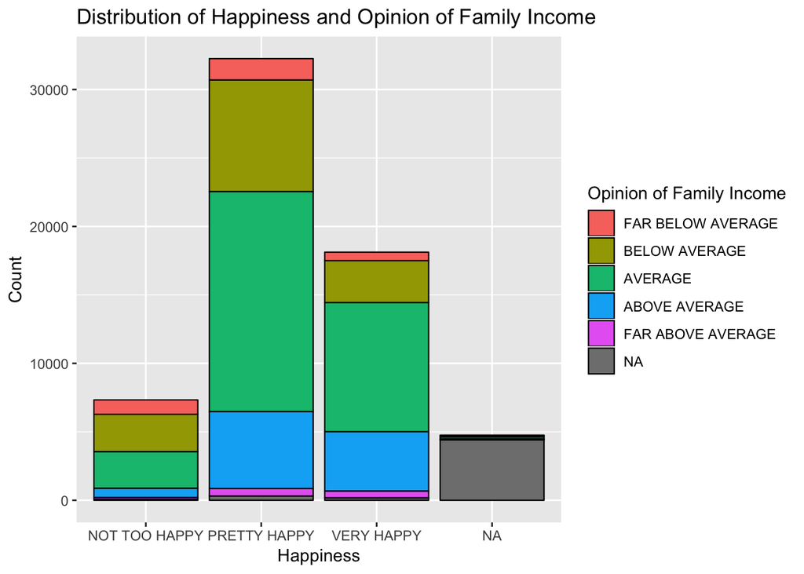

```r
#distribution of degree by sex
ggplot(HAPPY, aes(x=HAPPY, fill=FINRELA))+ geom_bar(na.rm = TRUE, color= "black", size = 0.4) + ggtitle("Distribution of Happiness and Opinion of Family Income") + ylab("Count") + xlab("Happiness") + guides(fill=guide_legend(title="Opinion of Family Income"))
```

As you can see here, there is certainly a noticeable difference in happiness depending one someone’s sex. More females would consider themselves to be “pretty happy” than males, however this could potentially be explained by the fact that there are more females than males within the dataset. As for the relationship between financial stability and happiness, it would appear that those who are below or far below average in their opinion of their financial success are more likely to be unhappy.